# Cost per kilometre by fuel source

Electric, petrol, diesel and plug-in hybrid in Denmark, 2026 - and the point at which the cheapest kilometre stops being the cheapest car

06 September 2026

> **The framing is deliberately split in three.** Sections 2 to 6 hold the car fixed and ask what a kilometre costs to produce, including the “periodiske afgifter” that the state ties directly to fuel type and fuel economy. Section 7 removes the confounds in the fleet by comparing a representative car of each fuel type **at the same odometer**, on a running cost that contains no capital at all - that is the cleanest answer to “which powertrain is cheapest to run”. Section 8 puts the capital back and asks the question a buyer actually faces: **how much more may the cheaper-to-run car cost and still be the cheaper car to own?**

> **Every number below is computed at knit time** from the parameter block in the source and from `fuel-cost-cars.csv`. Change an assumption, re-knit, and the prose moves with the tables. Section 1.1 says which inputs are sourced and which are judgement.

## Your inputs

| Input | Setting | Parameter |
| --- | --- | --- |
| Annual distance | 20,000 km/yr | `my_km_aar` |
| Years you expect to keep the car | 8 yr | `my_years` |
| Where you charge | House, night charging | `my_profile` |
| Blended electricity price that implies | 1.59 DKK/kWh | `(derived)` |
| Petrol, central | 17.91 DKK/l | `petrol_dkk_l` |
| Diesel, central | 18.41 DKK/l | `diesel_dkk_l` |
| Real-world consumption vs WLTP, ICE | x 1.20 | `gap_ice` |
| Real-world consumption vs WLTP, electric | x 1.25 | `gap_ev` |
| Real opportunity cost of capital | 3.0 % | `capital_rate` |
| Repair hazard ramp beyond 100,000 km | 0.25 DKK/km per 100,000 km | `hazard_slope` |

## 1. What “cost per kilometre” is being measured

A kilometre has two quite different costs attached to it, and mixing them is the standard way this comparison goes wrong.

**Marginal cost** is what the kilometre itself causes: the energy burnt, the tyre rubber left on the road, the service interval brought forward, the consumables used, the risk of an unscheduled repair moved closer, and the resale value the odometer destroys. If the car is already bought and parked outside, this is the cost of choosing to drive it.

**Fixed cost** is what the year causes whether the car moves or not: “ejerafgift”, insurance, the value lost to the calendar, and the return the purchase price would have earned elsewhere. Divided by distance it *looks* like a cost per kilometre, but it is not caused by the kilometre; it is caused by owning the car.

The question as posed - which fuel costs least per average driven kilometre, holding distance equal - is a question about marginal cost, and on that question there really is no trade-off. Sections 2 to 5 answer it.

### 1.1 Where these numbers come from

| Input | Status | Basis |
| --- | --- | --- |
| Petrol and diesel pump prices | **Sourced** | National list prices, early September 2026 |
| Electricity tariffs and the 2026 “elafgift” cut | **Sourced** | skat.dk on the 2026-27 rate; elberegner.dk on the all-in household price; ladetjek.dk on public charging |
| bZ4X Touring price and WLTP consumption | **Sourced** | Toyota Danmark |
| Toyota service tariff | **Sourced** | Toyota Koege price calculator, as used in the battery-warranty note |
| Odometer elasticity of used prices | **Estimated here** | `mileage_elasticity.R` on this repository’s bilbasen scrape; see 5.4 |
| Used comparator prices | **Listings** | `comparator_prices.R` on real bilbasen listings, for 6 of 10 used cars; audit trail in `comparator-listings.csv` |
| Other cars: prices, consumption, service | Placeholder | Consumption, weight and service costs throughout, and the prices of the cars listed below |
| Real-world consumption gap over WLTP | Judgement | Section 3. The single widest of the judgement calls |
| Tyre price and life, and their weight scaling | Judgement | Section 5.2 |
| Consumables and wear per km | Judgement | Section 5.3 |
| Repair hazard beyond 100,000 km | Judgement | Section 5.5, which inverts it rather than defending it |
| “Ejerafgift” and insurance per car | Placeholder | Order-of-magnitude only; matters in section 8, not before |
| Opportunity cost of capital | Carried over | `leasing_vs_kontant.Rmd` |

**Prices matter more than any other input here**, because section 8’s whole answer - the break-even cash price - is arithmetic on them. A comparator that is out by 30,000 DKK moves the conclusion further than any energy-price assumption in this document. So the used prices are no longer guesses: `comparator_prices.R` matches each car against real bilbasen listings on make, model, fuel, a registration-year window and a variant pattern that identifies all-wheel drive, then fits `log(price) ~ log(mileage)` and reads the price off at that car’s odometer.

**4 used comparators could not be priced that way and remain estimates**: VW Tiguan 2.0 TSI 4Motion (2020), Skoda Octavia Combi 2.0 TDI 4x4 (2019), Hyundai Tucson 1.6 CRDi AWD (2017), and VW Passat Variant 2.0 TDI 4Motion (2015). The scrape returned too few matching listings - in the case of the all-wheel-drive diesel wagons, none at all. That is itself informative, and it is the same finding as section 1.3 from a different direction: **all-wheel drive is rare enough in these classes that the Danish used market barely prices it.** But it does mean those rows are judgement, and one of them is the diesel reference car, so section 8’s diesel column should be read with more caution than its petrol column.

The new cars are a separate case. Their prices are list prices rather than listings: sourced for the Toyota bZ4X Touring AWD Active Tech and Skoda Enyaq 85x Selection AWD, and secondary or indicative for the rest. Consumption, weight and service costs are estimates for every car except the bZ4X and the new Enyaq.

### 1.2 Why this is a range and not a number

Almost every input here is a range, and the ranges come from three different places, which is worth keeping straight.

**Choices.** Electricity varies by a factor of **5.0** between a cheap night at home and an ad-hoc DC charger, and which rung you stand on is a consequence of where you live and how you drive. That is not an uncertainty to be averaged away; it means the answer for a driver with a driveway and the answer for one without are different answers to the same question.

**Dispersion at a moment.** Petrol costs about 0.80 DKK/l more at a motorway station than at an unmanned discount pump. Small, and largely under your control.

**Movement over the holding period.** This is the big one, and it is easily conflated with the previous item. Over 8 years the *level* of energy prices can move by several kroner a litre - the household electricity price alone ran from 1.57 to 3.17 DKK/kWh between 2020 and 2022. Today’s pump prices are at or near record highs, so a band drawn tightly around them would describe the wrong risk entirely. The bands used here are drawn from that history and are set out in section 2.4.

### 1.3 Every car here is all-wheel drive, and that is not free

The reference car is the AWD trim, so every comparator is AWD too. Holding the drivetrain fixed is the right call - a front-wheel-drive comparator would be cheaper, lighter and more economical for reasons that have nothing to do with its fuel, and the comparison would silently credit those to the powertrain. But the constraint is not costless, and it is worth being explicit about what it does before reading any of the numbers.

**It taxes the electric car too.** The bZ4X Touring is 153 Wh/km with the rear motor against 140 Wh/km without it - a 9 % energy penalty, plus about 135 kg of extra weight on the tyres. The AWD requirement is not a thumb on the scale for either side.

**It moves the whole fleet upmarket and narrows it sharply.** All-wheel drive is usually reserved for the larger engines and higher trims, which is why there is no AWD petrol Octavia in Denmark at all - the only Octavia sold with 4x4 is the 2.0 TDI. The consequence for this note is concrete:

| Condition | Fuel | Cars | Cheapest | Dearest | At or under 370,000 DKK |
| --- | --- | --- | --- | --- | --- |
| New | Petrol | 1 | 449,990 | 449,990 | 0 |
| New | Electric | 3 | 364,990 | 374,995 | 2 |
| Used | Petrol | 3 | 118,500 | 249,000 | 3 |
| Used | Diesel | 4 | 104,000 | 190,000 | 4 |
| Used | Electric | 2 | 222,500 | 264,500 | 2 |
| Used | Plug-in hybrid | 1 | 312,000 | 312,000 | 1 |

**No new all-wheel-drive combustion car in this class comes in under the 370,000 DKK cap.** The cheapest here is the Toyota RAV4 Hybrid AWD-i at 449,990 DKK, which is 79,990 DKK over it, against 364,990 DKK for the cheapest new AWD electric car. It is carried anyway rather than dropped, because excluding it would leave the new-car comparison empty and quietly convert a finding into an assumption. **That the cap and the drivetrain requirement together rule out new combustion rivals is itself part of the answer**, and it is a separate reason from cost - see section 8.4.

One caveat on the modelling. All-wheel drive adds a transfer case, a propshaft and a rear differential to every car here, so its contribution to the repair hazard is common to the fleet and cancels out of the comparison. It would *not* cancel between a permanent symmetrical system and an on-demand clutch-pack one, which are different pieces of engineering with different failure modes. That distinction is not modelled.

### 1.4 Can fuel cost be isolated from the price of the car, and at what mileage?

Two methodological questions, and they have different answers.

**Can the running cost be separated from the cash price? Yes, almost entirely.** Of the six marginal components, five are properties of the car and the driving, not of what was paid: energy, tyres, scheduled servicing, consumables and repair hazard. The “periodiske afgifter” in section 6 are the same - a bracket table on fuel economy and emissions, blind to the invoice. Only **one** component couples running cost to price, and that is the value the odometer destroys, which is proportional to what the car is worth. So the note carries a sixth quantity alongside the others:

> **Price-free running cost** = energy + tyres + service + consumables + repair hazard + “periodiske afgifter”, per km.

> It contains no capital at all. Two cars can be compared on it whatever they cost, and section 7 does exactly that.

It is not additive with total cost - the tax appears again inside the fixed costs in section 8 - so it is a *view* of a car, not a component of one.

**At what mileage? That question should not be answered, it should be removed.** The fleet in `fuel-cost-cars.csv` still confounds three things at once even with drivetrain now held fixed: the oldest combustion car in it, at 265,000 km, differs from a new bZ4X in powertrain *and* odometer *and* price. Picking one odometer to compare at would just be choosing which confound to keep.

The alternative is to make the odometer an axis rather than an assumption: build a representative car of each fuel type from the fleet medians, then evaluate all four at the **same** odometer, sweeping it across the range a buyer would actually consider. Nothing then has to be chosen, and the reader can see whether the ranking is stable in the odometer or crosses somewhere. That is section 7, and it is the part of this note that most directly answers “which type of car is cheapest in the long run”.

## 2. Energy prices

### 2.1 Pump prices, and the reversal nobody expected

DKK per litre incl. VAT. Today’s figure is the September 2026 national list price; the range is what the level could do over an 8-year hold - see section 2.4

| Fuel | Today (list) | Low over 8 yr | High over 8 yr |
| --- | --- | --- | --- |
| Petrol 95 (E10) | 17.91 | 13.50 | 23.00 |
| Diesel (B7) | 18.41 | 13.00 | 24.00 |

**Diesel now costs more per litre than petrol in Denmark** - 18.41 against 17.91, a reversal of the historical 0.50 to 1.50 DKK/l discount. The green tax reform pushed the CO2 duty on diesel above the duty on petrol, and diesel is the more carbon-dense fuel per litre. Diesel cars are still cheaper per kilometre, but now only because they burn fewer litres, not because the litres are cheaper - and the compensating **“udligningsafgift”** on the annual “ejerafgift” claws part of that back. The old rule of thumb that diesel pays off above some annual distance is now working against a materially worse starting position than it was three years ago.

Both fuels are also on a known upward path: road transport enters the EU emissions trading system in 2027, which is expected to add more than a krone to the litre price of both.

### 2.2 The electricity ladder

Electricity is not a price; it is a ladder, and which rung you stand on is the largest single determinant of an electric car’s running cost.

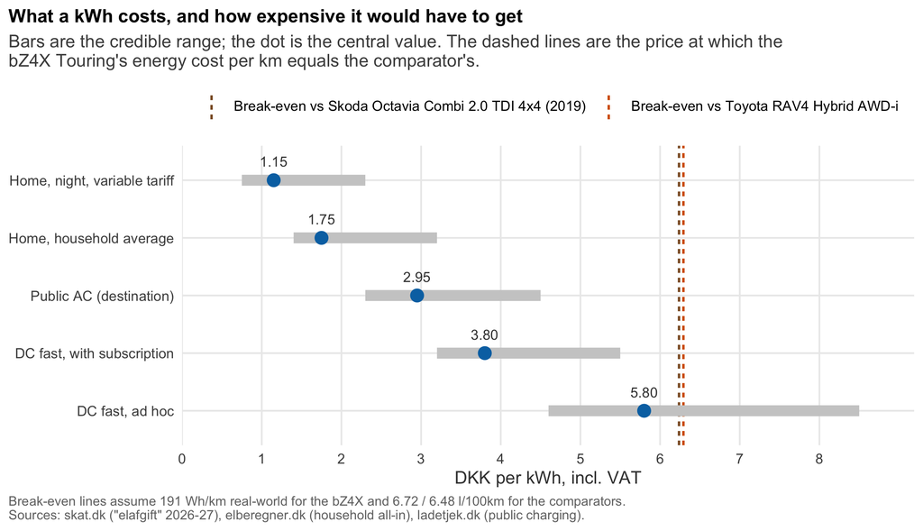

Two things are visible at once. **Every home tariff sits far below both break-even lines**, so a driver who charges at home is not close to the margin - the electric car’s energy is cheaper by a factor of 3.9 and no plausible movement in the spot price changes that. But **ad-hoc DC fast charging at 5.80 DKK/kWh is still below the diesel break-even line**, and at the top of its range, 8.50 DKK/kWh, an electric car bought to be charged on the road is burning more money per kilometre than the petrol wagon.

The 2026 tax position is what makes the home end of the ladder so favourable. The **“elafgift” was cut to 0.8 oere/kWh** (1 oere including VAT) for 2026 and 2027, from 90 oere in 2025 - close to a krone per kWh off the home price. This is a temporary measure with a legislated end date, and section 9.3 shows what its expiry does to the comparison.

### 2.3 What your charging profile costs

| Profile | Home % | DC % | DKK/kWh | bZ4X energy, DKK/km | vs new petrol |
| --- | --- | --- | --- | --- | --- |
| **House, night charging** | 85 % | 10 % | 1.59 (1.15-2.87) | 0.31 | 3.9x cheaper |
| House, no smart control | 85 % | 10 % | 2.02 (1.60-3.50) | 0.39 | 3.1x cheaper |
| Long-distance driver | 50 % | 45 % | 2.66 (2.10-4.20) | 0.51 | 2.4x cheaper |
| Flat, no home charger | 0 % | 45 % | 3.53 (2.84-5.25) | 0.68 | 1.8x cheaper |

Even the worst profile in the table - a flat with no home charger, everything bought on public infrastructure - leaves the electric car ahead of the new petrol wagon on energy. That is the 2026 answer, and it is a stronger answer than it was in 2025.

### 2.4 Where today’s price sits in its own history

Today’s pump prices are at or near record highs, and a range of a few øre either side of a record is not a credible description of what an eight-year hold is exposed to. The bands used in this note are drawn from the following history instead.

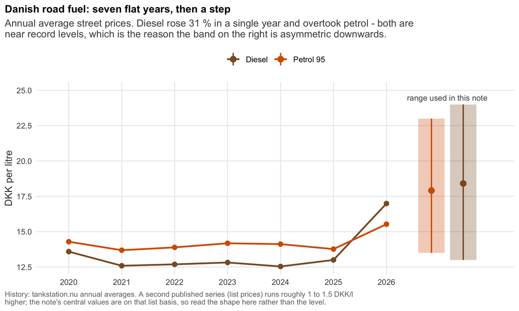

Three things follow.

**The step is recent and it is large.** Diesel spent 2020-2025 in a band of barely a krone and then rose 31 % in a single year, overtaking petrol. A level reached that recently, that fast, is not a safe base case to hold flat for eight years.

**So the band is asymmetric downwards, deliberately.** The low end is not a crash scenario; it is a return to where both fuels sat in 2024-25. The high end is a 2022-style shock arriving on top of the ETS2 duty increase due in 2027. Neither tail is exotic - both have happened inside the last six years.

**Electricity gets the same treatment, and needs it more.** The household all-in price ran 1.57 DKK/kWh in 2020 and 3.17 in 2022 - a factor of 2.0, wider in proportion than anything road fuel did in the same period. Widening the petrol band while leaving electricity at a few øre either side of today would have quietly rigged the comparison, so both were widened together.

> **One thing the bands do not capture.** The low, central and high settings move petrol, diesel and electricity **together**, because that is what happened in 2022: an energy shock raises all of them. That is the correlated case, and it is the *favourable* one for a comparison - it partly cancels. The genuinely awkward scenario is the decorrelated one, cheap oil with expensive electricity, and no single band can show it. Section 9.1 varies the two independently for exactly that reason, and section 9.4 asks how far petrol alone would have to fall.

## 3. From WLTP to the road

WLTP is a laboratory cycle run at 23 degrees with no heater, no roof box and no headwind. Real Danish consumption is higher, and it is higher by different amounts for different powertrains.

For a combustion car the gap is mostly cold starts, short trips and motorway speed: a multiplier of about 1.20 centrally, 1.10 to 1.32 across the range. For an electric car the same effects apply and one more is added on top - cabin heating comes out of the traction battery rather than out of waste engine heat, and in a Danish winter that is a large draw. The central multiplier here is 1.25, range 1.12 to 1.42.

This asymmetry is real and it works against the electric car, so it is worth being explicit that **it is a judgement call, not a measurement**, and one of the widest in the note. It is also self-limiting: because electricity is so much cheaper per unit of energy, even the high end of the EV gap does not close the energy gap.

| Car | Fuel | Type approval | Real world | Energy, DKK/km | Energy per 1,000 km |
| --- | --- | --- | --- | --- | --- |
| Toyota bZ4X Touring AWD Active Tech | Electric | 153 Wh/km | 191 Wh/km | 0.31 | 305 |
| Skoda Enyaq 85x Selection AWD | Electric | 155 Wh/km | 194 Wh/km | 0.31 | 309 |
| Tesla Model Y Long Range AWD | Electric | 150 Wh/km | 188 Wh/km | 0.30 | 299 |
| Skoda Enyaq 85x AWD (2022) | Electric | 178 Wh/km | 222 Wh/km | 0.35 | 355 |
| Tesla Model Y Long Range AWD (2021) | Electric | 168 Wh/km | 210 Wh/km | 0.33 | 335 |
| Toyota RAV4 Hybrid AWD-i | Petrol | 5.6 l/100km | 6.7 l/100km | 1.20 | 1,204 |
| VW Tiguan 2.0 TSI 4Motion (2020) | Petrol | 8.2 l/100km | 9.8 l/100km | 1.76 | 1,762 |
| Subaru Outback 2.5i AWD (2019) | Petrol | 8.6 l/100km | 10.3 l/100km | 1.85 | 1,848 |
| Subaru Forester 2.0 AWD (2013) | Petrol | 8.9 l/100km | 10.7 l/100km | 1.91 | 1,913 |
| Skoda Octavia Combi 2.0 TDI 4x4 (2019) | Diesel | 5.4 l/100km | 6.5 l/100km | 1.19 | 1,193 |
| Volvo XC60 D4 AWD (2016) | Diesel | 6.2 l/100km | 7.4 l/100km | 1.37 | 1,370 |
| Hyundai Tucson 1.6 CRDi AWD (2017) | Diesel | 6.3 l/100km | 7.6 l/100km | 1.39 | 1,392 |
| VW Passat Variant 2.0 TDI 4Motion (2015) | Diesel | 5.8 l/100km | 7.0 l/100km | 1.28 | 1,281 |
| Toyota RAV4 Plug-in Hybrid AWD (2021) | Plug-in hybrid | 220 Wh/km | 275 Wh/km + 8.2 l/100km | 0.90 | 899 |

The plug-in hybrid carries a caveat the others do not. Its cost depends on the **electric share** - here 55 % - which is not a property of the car but of how disciplined the owner is about plugging it in. A plug-in hybrid that is never charged is a heavy petrol SUV; one that is charged every night is an electric car with a petrol reserve. It is the one powertrain for which “assume the same kilometres” is not enough to pin down the cost.

## 4. The headline: marginal cost per kilometre

### 4.1 The comparison, with its ranges

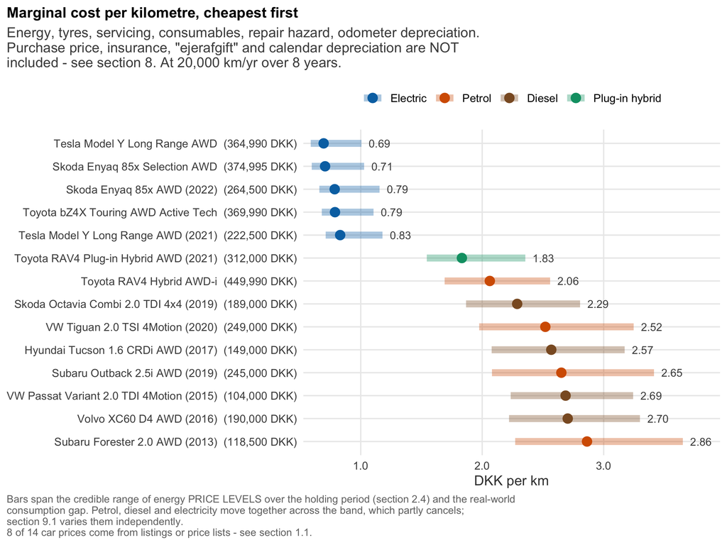

Three things stand out.

**The gap is bigger than the energy prices suggest, not smaller.** The bZ4X is 127.5 oere/km cheaper than the new petrol wagon, against an energy gap of 89.9 oere/km. The extra 37.6 oere/km is almost entirely one component - the value the odometer destroys - and it rests on the weakest estimate in the note. Section 5.4 sets out why the electric depreciation elasticity should not be trusted at face value, and section 9.2 bounds what it can do.

### 4.2 Where the money actually goes

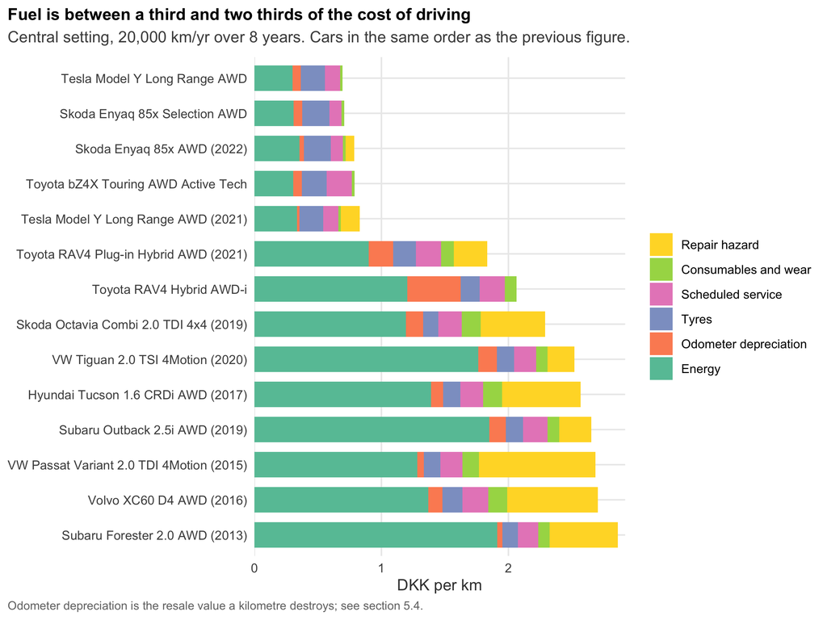

Energy is 39 % of the bZ4X’s marginal cost and 58 % of the new petrol wagon’s. **A comparison built on pump and charger prices alone is arguing about roughly half the money**, and the half it leaves out is not neutral between the two: for the newest and most expensive cars the second-largest component is the value the odometer removes, and for the oldest it is the repair hazard. Both of those cut across fuel type rather than along it.

The one component that clearly favours combustion is tyres, and only because of weight. It is worth 4.8 oere/km, against 7.0 oere/km the other way on consumables. Those two very nearly cancel, which is why the energy advantage passes through to the bottom line almost undiminished.

### 4.3 The one axis that changes the electric answer

Charging habits move the electric cars and nothing else, so they are shown on their own axis rather than folded into the range.

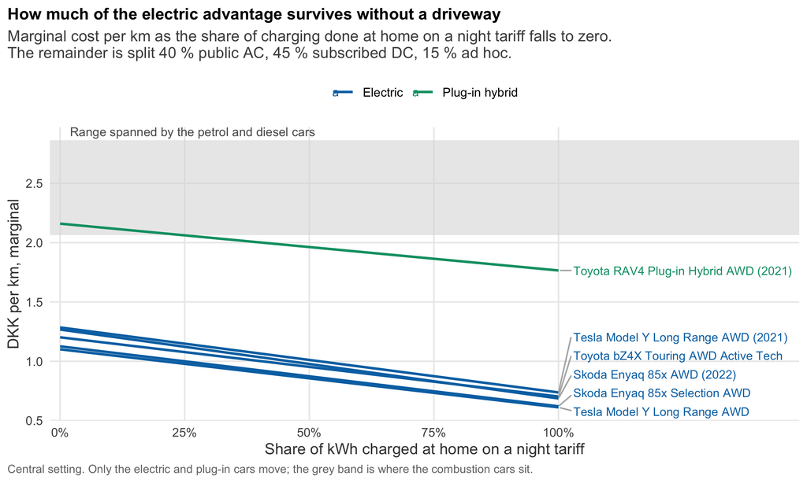

## 5. The components that are not fuel

### 5.1 Scheduled servicing

Service is priced from the alternating small/large schedule each manufacturer publishes, at whichever comes first of the distance and the time interval. The Toyota figures are the same sourced tariff used in the battery-warranty note; the others are placeholders.

Applying the time limit matters more than it looks. At 20,000 km/yr the distance interval binds for 14 of the 14 cars, but at 8,000 km/yr it binds for 0 - a low-mileage driver pays for the same services over fewer kilometres, and per-kilometre service cost rises accordingly. Ignoring that would have flattered every low-distance scenario, which is exactly the region where the answer is closest.

### 5.2 Tyres, and the weight penalty

| Car | Kerb weight | Set of four | Life | DKK/km |
| --- | --- | --- | --- | --- |
| Skoda Enyaq 85x Selection AWD | 2,180 kg | 6,387 | 29,827 km | 0.21 |
| Skoda Enyaq 85x AWD (2022) | 2,170 kg | 6,371 | 29,978 km | 0.21 |
| Toyota bZ4X Touring AWD Active Tech | 2,065 kg | 6,200 | 31,659 km | 0.20 |
| Tesla Model Y Long Range AWD | 2,022 kg | 6,128 | 32,401 km | 0.19 |
| Tesla Model Y Long Range AWD (2021) | 2,003 kg | 6,096 | 32,739 km | 0.19 |
| Toyota RAV4 Plug-in Hybrid AWD (2021) | 1,950 kg | 6,007 | 33,719 km | 0.18 |
| Volvo XC60 D4 AWD (2016) | 1,810 kg | 5,766 | 36,599 km | 0.16 |
| Toyota RAV4 Hybrid AWD-i | 1,740 kg | 5,642 | 38,222 km | 0.15 |
| VW Tiguan 2.0 TSI 4Motion (2020) | 1,660 kg | 5,498 | 40,253 km | 0.14 |
| Subaru Outback 2.5i AWD (2019) | 1,660 kg | 5,498 | 40,253 km | 0.14 |
| Hyundai Tucson 1.6 CRDi AWD (2017) | 1,650 kg | 5,480 | 40,521 km | 0.14 |
| VW Passat Variant 2.0 TDI 4Motion (2015) | 1,620 kg | 5,425 | 41,347 km | 0.13 |
| Subaru Forester 2.0 AWD (2013) | 1,550 kg | 5,295 | 43,406 km | 0.12 |
| Skoda Octavia Combi 2.0 TDI 4x4 (2019) | 1,520 kg | 5,238 | 44,349 km | 0.12 |

The bZ4X Touring AWD weighs 2,065 kg, 325 kg more than the Toyota RAV4 Hybrid AWD-i, and that weight has to be carried on four contact patches and stopped by four tyres. Both the price of a set and the rate it wears scale with it. The result is 4.8 oere/km against the electric car - which is 5 % of the energy advantage handed straight back.

Two exponents drive this and both are judgement: `tyre_price_exp` = 0.55 and `tyre_wear_exp` = 1.1. Setting them both to zero, so that weight has no effect at all, would move the electric-versus-petrol marginal gap by 4.8 oere/km. Not decisive on its own; not negligible either.

A note on Danish practice: most drivers run two seasonal sets. That doubles the tyre *stock* but not the wear per kilometre, so it is a fixed cost of a few hundred kroner a year in storage and changeovers, not a marginal one, and it is left out here.

### 5.3 Consumables and wear

0.02 DKK/km for electric, 0.09 for petrol, 0.13 for diesel, plus 0.02 where AdBlue is used. These cover what falls outside the service schedule: oil top-ups, brake pads and discs, exhaust, spark or glow plugs, EGR valves and particulate filters.

The electric figure is low for two structural reasons, not one. There is no oil, no filter and no plug; and regenerative braking means the friction brakes are used so lightly that pads and discs often outlast the car. The 11.0 oere/km spread between diesel and electric is a judgement, but the *sign* and rough magnitude are not seriously in dispute.

### 5.4 What the odometer does to resale value

This is the component most often left out of fuel comparisons and it is frequently the largest one. A kilometre driven does not only burn energy - it removes value from the car, and how much depends on the fuel type.

The elasticities are estimated in `mileage_elasticity.R` from this repository’s own bilbasen scrape, fitting `log(price) ~ age + log(mileage) + log(hk) + brand` within each fuel group.

| Fuel | Listings | Elasticity | Without controls | R-squared | Median odometer |
| --- | --- | --- | --- | --- | --- |
| Electric | 3,365 | -0.044 (se 0.005) | 0.096 | 0.83 | 36,000 km |
| Petrol | 3,032 | -0.209 (se 0.007) | -0.060 | 0.90 | 95,000 km |
| Diesel | 491 | -0.385 (se 0.030) | -0.147 | 0.88 | 160,000 km |

Read the elasticity as: a 1 % higher odometer goes with `|e|` % lower asking price, holding age, power and brand constant. Petrol at -0.209 and diesel at -0.385 are both large and precisely estimated. Diesel’s is nearly twice petrol’s, which fits the market: diesels are bought *for* distance, and a high-mileage diesel is competing against a lot of other high-mileage diesels.

**The electric estimate is the fragile one and must be flagged.** At -0.044 it implies the odometer barely matters for an EV’s resale. But without the power and brand controls the same regression returns **0.096** - the wrong sign entirely, because in the Danish used-EV market the cars with high mileage are disproportionately the expensive long-range ones. A coefficient whose sign depends on the controls is not something to build a conclusion on. It flatters the electric cars here, and section 9.2 scales all three elasticities to show by how much.

Two further caveats apply to all three. These are **asking prices in a cross-section**, not transaction prices on the same car over time, so any unobserved reason that high-mileage cars differ from low-mileage ones is loaded onto the coefficient. And they are fitted between the 25th and 75th percentile odometers in the table; extrapolating to 300,000 km is extrapolation.

| Car | Price | Odometer at purchase | After 8 yr | Value the km destroy | DKK/km |
| --- | --- | --- | --- | --- | --- |
| Toyota RAV4 Hybrid AWD-i | 449,990 | 0 | 160,000 | 67,499 | 0.42 |
| Toyota RAV4 Plug-in Hybrid AWD (2021) | 312,000 | 95,000 | 255,000 | 30,983 | 0.19 |
| VW Tiguan 2.0 TSI 4Motion (2020) | 249,000 | 105,000 | 265,000 | 23,328 | 0.15 |
| Skoda Octavia Combi 2.0 TDI 4x4 (2019) | 189,000 | 155,000 | 315,000 | 21,709 | 0.14 |
| Subaru Outback 2.5i AWD (2019) | 245,000 | 121,000 | 281,000 | 21,067 | 0.13 |
| Volvo XC60 D4 AWD (2016) | 190,000 | 210,000 | 370,000 | 17,896 | 0.11 |
| Hyundai Tucson 1.6 CRDi AWD (2017) | 149,000 | 185,000 | 345,000 | 15,280 | 0.10 |
| Skoda Enyaq 85x Selection AWD | 374,995 | 0 | 160,000 | 10,943 | 0.07 |
| Toyota bZ4X Touring AWD Active Tech | 369,990 | 0 | 160,000 | 10,797 | 0.07 |
| Tesla Model Y Long Range AWD | 364,990 | 0 | 160,000 | 10,651 | 0.07 |
| VW Passat Variant 2.0 TDI 4Motion (2015) | 104,000 | 265,000 | 425,000 | 8,314 | 0.05 |
| Subaru Forester 2.0 AWD (2013) | 118,500 | 235,000 | 395,000 | 6,491 | 0.04 |
| Skoda Enyaq 85x AWD (2022) | 264,500 | 75,000 | 235,000 | 5,512 | 0.03 |
| Tesla Model Y Long Range AWD (2021) | 222,500 | 140,000 | 300,000 | 3,120 | 0.02 |

That single coefficient is worth 35.4 oere/km of the bZ4X’s advantage over the new petrol wagon, which is 28 % of the total gap between them. It is also the coefficient whose sign flips when the controls change. If you distrust one number in this document, distrust that one - section 9.2 shows what happens when it is scaled, and the answer survives, but the margin does not survive intact.

### 5.5 Repair hazard: the number that decides the cheap cars

Beyond 100,000 km the model adds an expected unscheduled repair cost that ramps at 0.25 DKK/km per 100,000 km past the threshold, multiplied by 0.5 for electric, 1 for petrol and 1.5 for diesel. The diesel multiplier carries turbochargers, injectors, EGR valves and particulate filters, all of which are expensive and all of which fail on distance rather than on age.

This assumption is doing real work: it is what pushes the high-odometer cars to the *bottom* of the marginal-cost ranking despite their cheap fuel. So rather than defend the point estimate, here is what it would have to be to change the answer. The cheap end of the fleet is where the bZ4X’s real competition lives on **total** cost, so the inversion below is run on total cost, not marginal.

Total DKK/km, with marginal in brackets

| Car | slope = 0.10 | slope = 0.25 | slope = 0.45 |
| --- | --- | --- | --- |
| Toyota bZ4X Touring AWD Active Tech | 3.08 (0.79) | 3.08 (0.79) | 3.08 (0.79) |
| Subaru Forester 2.0 AWD (2013) | 3.41 (2.54) | 3.73 (2.86) | 4.16 (3.29) |
| Skoda Octavia Combi 2.0 TDI 4x4 (2019) | 3.24 (1.98) | 3.54 (2.29) | 3.95 (2.69) |
| Volvo XC60 D4 AWD (2016) | 3.61 (2.28) | 4.03 (2.70) | 4.60 (3.27) |
| Hyundai Tucson 1.6 CRDi AWD (2017) | 3.36 (2.20) | 3.73 (2.57) | 4.22 (3.06) |
| VW Passat Variant 2.0 TDI 4Motion (2015) | 3.02 (2.14) | 3.58 (2.69) | 4.31 (3.42) |

That is the number to have an opinion about, and it is not a question about fuel at all - it is a question about one specific car’s service history. Which is the honest finding for the cheap end of the market: **below about 100,000 DKK the powertrain stops being what decides the cost per kilometre**, and the individual car’s condition takes over. No amount of modelling substitutes for a mechanic’s inspection there.

## 6. The periodic taxes (“periodiske afgifter”)

The annual road tax is the one cost in this note that is a **direct function of fuel type and fuel economy**, written into statute. It is not an estimate, and it is not neutral between powertrains - it is the instrument the state uses to make them non-neutral. It is charged twice a year; everything below is the annual total.

### 6.1 Two regimes, split by registration date

Denmark runs two parallel systems and this fleet straddles the boundary.

- **“CO2-ejerafgift”** applies to cars first registered on or after 1 July 2021, on brackets of WLTP CO2 in g/km. Every battery-electric car sits in the bottom bracket at 920 DKK/yr.
- **“Grøn ejerafgift”** (“brændstofforbrugsafgift”) applies to everything registered before that, on brackets of fuel economy in km/l. An electric car’s consumption is converted by dividing Wh/km by the statutory factor 91.25 - which puts the fleet’s pre-2022 electric car, at 168 Wh/km, on 54 km/l equivalent, i.e. the top bracket.
- **Diesel pays an “udligningsafgift” on top** under both regimes, compensating for diesel’s historically lower duty at the pump.
- **“Vægtafgift”** is not modelled: it applies to petrol cars first registered before 1 July 1997, and nothing in the fleet is that old.

| Car | Fuel | Regime | Basis | DKK/yr | oere/km |
| --- | --- | --- | --- | --- | --- |
| Tesla Model Y Long Range AWD (2021) | Electric | km/l | 54.3 km/l eq. | 660 | 3.3 |
| Toyota bZ4X Touring AWD Active Tech | Electric | CO2 | 0 g/km | 920 | 4.6 |
| Skoda Enyaq 85x Selection AWD | Electric | CO2 | 0 g/km | 920 | 4.6 |
| Tesla Model Y Long Range AWD | Electric | CO2 | 0 g/km | 920 | 4.6 |
| Skoda Enyaq 85x AWD (2022) | Electric | CO2 | 0 g/km | 920 | 4.6 |
| Toyota RAV4 Hybrid AWD-i | Petrol | CO2 | 131 g/km | 1,600 | 8.0 |
| Toyota RAV4 Plug-in Hybrid AWD (2021) | Plug-in hybrid | km/l | 14.7 km/l | 1,840 | 9.2 |
| VW Tiguan 2.0 TSI 4Motion (2020) | Petrol | km/l | 12.2 km/l | 2,520 | 12.6 |
| Subaru Outback 2.5i AWD (2019) | Petrol | km/l | 11.6 km/l | 3,400 | 17.0 |
| Subaru Forester 2.0 AWD (2013) | Petrol | km/l | 11.2 km/l | 3,400 | 17.0 |
| Skoda Octavia Combi 2.0 TDI 4x4 (2019) | Diesel | km/l | 18.5 km/l | 3,440 | 17.2 |
| VW Passat Variant 2.0 TDI 4Motion (2015) | Diesel | km/l | 17.2 km/l | 4,240 | 21.2 |
| Volvo XC60 D4 AWD (2016) | Diesel | km/l | 16.1 km/l | 4,420 | 22.1 |
| Hyundai Tucson 1.6 CRDi AWD (2017) | Diesel | km/l | 15.9 km/l | 5,200 | 26.0 |

The spread across the fleet is 660 to 5,200 DKK a year. Electric cars pay 868 on average, petrol 2,730 and diesel 4,325 - the diesel figure carrying an “udligningsafgift” of 1,595 more than the petrol cars on top of a similar consumption charge. At 20,000 km/yr that is worth 17.3 oere/km between diesel and electric - real, but an order of magnitude smaller than the energy gap in section 2, which is why it changes the size of the answer rather than its sign.

### 6.2 What is modelled exactly and what is approximated

The **CO2 table is reproduced in full** from the official brackets, including the diesel “udligningsafgift” column, and it governs every car in the fleet registered from 2022. That is where the new-car decision actually sits, so the part that matters most is the part that is exact.

The **km/l side is a simplification and should be treated as such.** The statute runs four separate scales - petrol and diesel, each split at 3 October 2017 - and this note collapses them to one scale per fuel. Two known gaps:

- Secondary 2026 sources give the most efficient petrol bracket as 330 DKK per half-year while the official scale summary implies 460. The lower figure is used here. It affects only the top bracket, where every electric and hybrid car in the fleet sits, and the two differ by 260 DKK/yr.
- The “udligningsafgift” is only tabulated against CO2 in the source available, so pre-2021 diesels are charged the surcharge from their **CO2 bracket** rather than from the statutory km/l scale.

Neither moves the conclusions - the whole tax is a few tens of øre per kilometre - but **verify the exact kroner against Motorstyrelsen before quoting them**, and correct `periodic-tax-rates.csv` rather than the code if they differ.

### 6.3 The diesel relief expires

The “udligningsafgift” is currently cut by **30 %**, a temporary measure for 2025-26 that compensates diesel drivers for a 52 øre/l rise in the diesel duty. It falls to a 21 % cut from 2027.

Restoring the surcharge to its 2027 level raises the diesel cars’ annual tax by 291 DKK on average, or 1.5 oere/km at 20,000 km. Small on its own - but note the direction of travel: **the pump price and the periodic tax on diesel were deliberately moved in opposite directions, and the offset is being withdrawn from both ends.** Diesel already costs more per litre than petrol (section 2.1); from 2027 it also pays back more of the tax relief that was meant to compensate for it, and road transport enters the EU emissions trading system the same year. Anyone buying a diesel for an eight-year hold is buying into that trajectory, not into today’s numbers.

## 7. Fuel type at matched mileage

Section 4 ranked 14 specific cars. That ranking mixes powertrain with odometer and with price, which is fine for choosing between those 14 and useless for the general question. This section removes the confounds: a **representative car of each fuel type**, built from the fleet medians for consumption, weight and servicing, evaluated at the **same odometer**, on the price-free running cost defined in section 1.4.

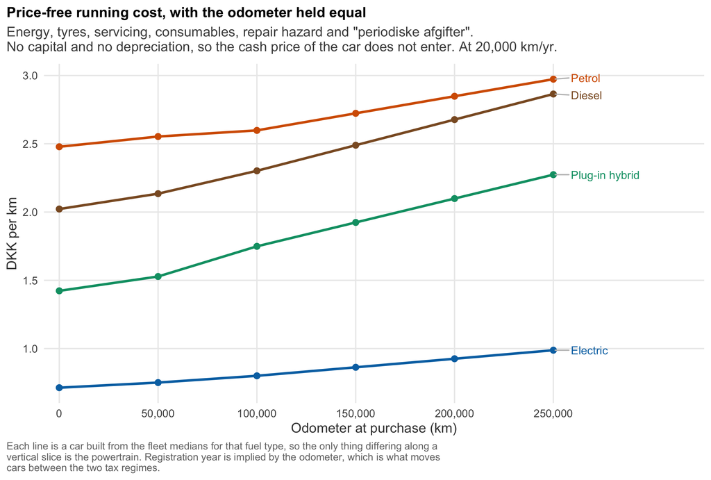

DKK/km price-free running cost, with the periodic tax in oere/km in brackets

| Fuel | 0 km | 100,000 km | 200,000 km |
| --- | --- | --- | --- |
| Electric | 0.71 (tax 5o) | 0.80 (tax 3o) | 0.93 (tax 3o) |
| Petrol | 2.48 (tax 25o) | 2.60 (tax 17o) | 2.85 (tax 17o) |
| Diesel | 2.02 (tax 23o) | 2.30 (tax 21o) | 2.68 (tax 21o) |
| Plug-in hybrid | 1.42 (tax 5o) | 1.75 (tax 9o) | 2.10 (tax 9o) |

**The ranking does not cross.** Electric is cheapest to run at every odometer on the grid, and no other fuel type is cheapest anywhere on it. The advantage over the best combustion alternative is 70.9 oere/km at zero km and 128.6 oere/km at 250,000 km, so it widens with age rather than reversing.

This is the cleanest statement the note can make about your actual question. It holds the odometer equal, so it is not an artefact of comparing new electric cars with worn-out diesels; it contains no capital, so it is not an artefact of what the cars cost. **On what it costs to run a car, the powertrain ranking in Denmark in 2026 is stable in the odometer and does not depend on price at all.**

> **What this deliberately leaves out.** Everything to do with capital: purchase price, depreciation and the return that money would otherwise earn. Those are the larger numbers, they run the other way, and section 8 puts them back. Read this section as *what a kilometre costs*, not as *which car to buy*.

> **And a caveat on the medians.** With 14 cars across four powertrains there are only three or four of each, so the median is not a robust central estimate. The petrol median here is 8.40 l/100km, pulled towards the thirsty used all-wheel-drive SUVs and away from the Toyota RAV4 Hybrid AWD-i at 5.60 - which widens the gap shown above. Section 8.4 uses one *named* car per powertrain instead, which is both the conservative choice and the attributable one.

## 8. Total cost of ownership, and the break-even cash price

Everything so far held the car fixed and asked what a kilometre costs. That question has no trade-off in it, and the electric cars won it outright. This section puts the purchase price back, and the trade-off appears immediately - because a 369,990 DKK car has to earn back roughly 45,885 DKK a year in “ejerafgift”, insurance, calendar depreciation and foregone return before its cheaper kilometres count for anything, and at 20,000 km/yr that is 2.29 DKK/km of fixed cost against 0.79 DKK/km of marginal cost. **The fixed side is the larger number.**

Total cost per kilometre at annual distance `d` is

$$c(d) \;=\; \underbrace{\frac{\text{"ejerafgift"} + \text{insurance} + \text{calendar depreciation} + \text{cost of capital}}{d}}_{\text{falls as } 1/d} \;+\; \underbrace{m(d)}_{\text{roughly flat}}$$

The first term is a hyperbola and the second is nearly a constant, so every car is a curve that falls steeply and then flattens. **The car with the lowest marginal cost wins only in the limit of infinite distance.** At any finite distance the curves cross.

### 8.1 What a year costs regardless of distance

Annual costs that distance does not cause, over a 8-year hold

| Car | Price | “Ejerafgift” | Insurance | Calendar dep. | Capital | Fixed, DKK/yr |
| --- | --- | --- | --- | --- | --- | --- |
| Subaru Forester 2.0 AWD (2013) | 118,500 | 3,400 | 4,400 | 6,928 | 2,626 | 17,354 |
| VW Passat Variant 2.0 TDI 4Motion (2015) | 104,000 | 4,240 | 4,600 | 6,754 | 2,185 | 17,779 |
| Hyundai Tucson 1.6 CRDi AWD (2017) | 149,000 | 5,200 | 5,200 | 9,676 | 3,080 | 23,156 |
| Skoda Octavia Combi 2.0 TDI 4x4 (2019) | 189,000 | 3,440 | 5,500 | 12,274 | 3,871 | 25,085 |
| Volvo XC60 D4 AWD (2016) | 190,000 | 4,420 | 5,900 | 12,339 | 3,951 | 26,610 |
| Tesla Model Y Long Range AWD (2021) | 222,500 | 660 | 6,100 | 16,108 | 4,695 | 27,563 |
| VW Tiguan 2.0 TSI 4Motion (2020) | 249,000 | 2,520 | 6,300 | 14,557 | 5,373 | 28,750 |
| Subaru Outback 2.5i AWD (2019) | 245,000 | 3,400 | 5,800 | 14,323 | 5,315 | 28,838 |
| Skoda Enyaq 85x AWD (2022) | 264,500 | 920 | 6,600 | 19,149 | 5,554 | 32,223 |
| Toyota RAV4 Plug-in Hybrid AWD (2021) | 312,000 | 1,840 | 7,000 | 18,240 | 6,706 | 33,787 |
| Tesla Model Y Long Range AWD | 364,990 | 920 | 8,000 | 28,728 | 7,343 | 44,990 |
| Toyota bZ4X Touring AWD Active Tech | 369,990 | 920 | 8,400 | 29,121 | 7,443 | 45,885 |
| Skoda Enyaq 85x Selection AWD | 374,995 | 920 | 8,300 | 29,515 | 7,544 | 46,279 |
| Toyota RAV4 Hybrid AWD-i | 449,990 | 1,600 | 8,200 | 29,900 | 8,899 | 48,600 |

### 8.2 The break-even distance between these 14 cars

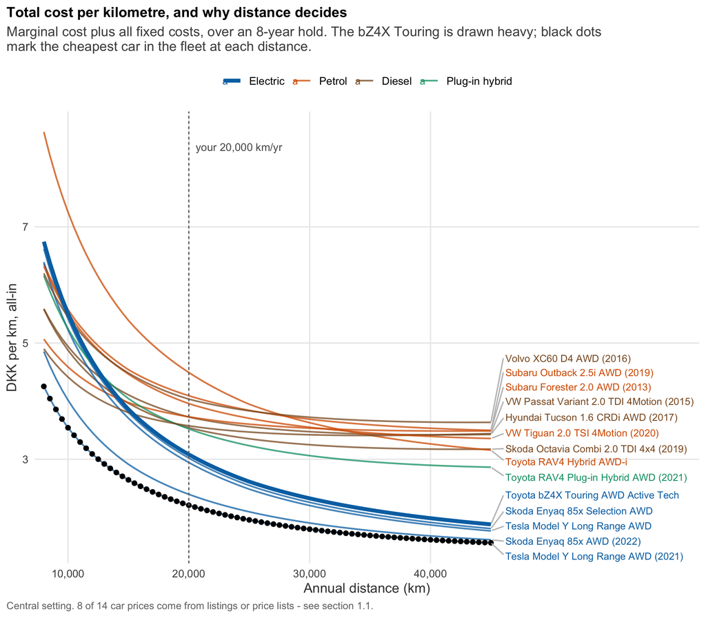

| bZ4X Touring vs | Fuel | Price | Gap at 20,000 km/yr | Break-even distance |
| --- | --- | --- | --- | --- |
| Toyota RAV4 Hybrid AWD-i | Petrol | 449,990 | bZ4X cheaper by 141.0 oere/km | never crosses |
| Subaru Outback 2.5i AWD (2019) | Petrol | 245,000 | bZ4X cheaper by 101.1 oere/km | 9,643 km/yr |
| Volvo XC60 D4 AWD (2016) | Diesel | 190,000 | bZ4X cheaper by 95.2 oere/km | 10,310 km/yr |
| VW Tiguan 2.0 TSI 4Motion (2020) | Petrol | 249,000 | bZ4X cheaper by 87.5 oere/km | 9,945 km/yr |
| Subaru Forester 2.0 AWD (2013) | Petrol | 118,500 | bZ4X cheaper by 64.8 oere/km | 14,232 km/yr |
| Hyundai Tucson 1.6 CRDi AWD (2017) | Diesel | 149,000 | bZ4X cheaper by 64.4 oere/km | 13,066 km/yr |
| VW Passat Variant 2.0 TDI 4Motion (2015) | Diesel | 104,000 | bZ4X cheaper by 49.3 oere/km | 15,415 km/yr |
| Skoda Octavia Combi 2.0 TDI 4x4 (2019) | Diesel | 189,000 | bZ4X cheaper by 46.0 oere/km | 14,036 km/yr |
| Toyota RAV4 Plug-in Hybrid AWD (2021) | Plug-in hybrid | 312,000 | bZ4X cheaper by 44.0 oere/km | 12,523 km/yr |
| Skoda Enyaq 85x Selection AWD | Electric | 374,995 | bZ4X dearer by 6.2 oere/km | never crosses |
| Tesla Model Y Long Range AWD | Electric | 364,990 | bZ4X dearer by 13.8 oere/km | never crosses |
| Skoda Enyaq 85x AWD (2022) | Electric | 264,500 | bZ4X dearer by 68.5 oere/km | never crosses |
| Tesla Model Y Long Range AWD (2021) | Electric | 222,500 | bZ4X dearer by 87.3 oere/km | never crosses |

At 20,000 km/yr the bZ4X Touring is cheaper all-in than 9 of the 13 comparators and dearer than 4. Against 8 of them there is a genuine break-even distance, ranging from 9,643 to 15,415 km/yr: drive more than that and the bZ4X’s cheaper kilometres have paid for its price. Against the remaining 5 the curves never cross inside 2,000 to 80,000 km/yr - one car simply dominates the other at every distance a private owner would drive, and no amount of driving fixes it.

**Holding the car fixed, the cheapest fuel wins and there is nothing to weigh** - the electric cars took the top 5 places in section 4. Allowing the car to vary across a 104,000 to 449,990 DKK range turns it into a capital-versus-running-cost problem, and the cheapest car all-in at 20,000 km/yr becomes the **Tesla Model Y Long Range AWD (2021)** at 2.21 DKK/km, against 3.08 for the bZ4X. The question stops being *which fuel is cheapest* and becomes *how far do I drive, and is that far enough to amortise the price difference*.

### 8.3 Average annual cost over 8 years, by fuel type

The break-even distances above still compare 14 particular cars. Applying the section 7 device - a representative car per fuel type, all at the same odometer - and sweeping the cash price turns the comparison into the one a buyer actually faces: *what may this car cost, given what it will cost to run?*

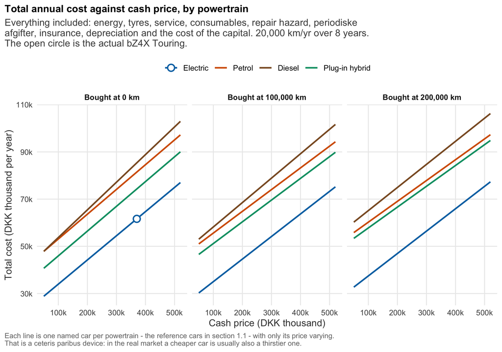

The lines are close to parallel, and that is the substantive point. The **slope** is what a krone of purchase price costs per year - depreciation plus foregone return, around 10.2 % a year for an electric car - and it barely differs between powertrains. The **vertical gaps between the lines** are the running-cost differences from section 7. Dividing one by the other gives the number the decision turns on.

### 8.4 The break-even cash price

> **How much may an electric car cost and still be no more expensive to own than a combustion one?**

Cash price at which a combustion car matches an electric one bought for 369,990 DKK, on total annual cost

| Fuel | At 0 km | At 100,000 km | At 200,000 km |
| --- | --- | --- | --- |
| Petrol | 181,266 | 156,843 | 132,250 |
| Diesel | 167,493 | 125,626 | 78,912 |
| Plug-in hybrid | 249,497 | 205,102 | 159,936 |

**A new electric car bought for 369,990 DKK costs the same per year to own as a petrol car bought for 181,266 DKK.** The electric car may therefore cost **188,724 DKK more** at the till and still break even over 8 years at 20,000 km. Against the other powertrains the allowance is 202,497 DKK vs diesel and 120,493 DKK vs plug-in hybrid.

Read the other way it is a rule of thumb worth carrying into a showroom: at 20,000 km/yr an electric car is worth **190,000 DKK more than an equivalent petrol car**, and at least **120,000 DKK more** than the closest-run alternative in the fleet, the plug-in hybrid. Below that premium it wins on total cost; above it, the cheaper kilometres do not repay the capital.

**181,266 DKK is below the cheapest new combustion car in the fleet** (Toyota RAV4 Hybrid AWD-i at 449,990 DKK), and well below anything of this size on sale. So at 20,000 km/yr the comparison against *new* combustion cars is not a premium at all - it is a dominance result: no new petrol or diesel wagon in this class can be bought cheaply enough to match the electric car on total cost. The real competition is the used market, which is what the 100,000 and 200,000 km columns above are for.

The premium is not a constant - it scales with how far you drive, because that is what turns a per-kilometre advantage into kroner:

| Annual distance | Break-even petrol price | Electric premium justified |
| --- | --- | --- |
| 10,000 km | 276,869 | 93,121 |
| 15,000 km | 227,552 | 142,438 |
| 20,000 km | 181,266 | 188,724 |
| 30,000 km | 86,458 | 283,532 |
| 40,000 km | none exists | any price wins |

The rows marked *none exists* are not a failure of the solver. Above about 40,000 km/yr the electric car is cheaper per year than a petrol car at **any** purchase price down to the 20,000 DKK floor of the search - the running-cost gap over 8 years exceeds the entire value of a cheap petrol car, so no discount closes it.

> **Three caveats before using this number.** The comparator is the Toyota RAV4 Hybrid AWD-i at its published 5.60 l/100km, with only its price varying. That is the most efficient all-wheel-drive petrol car in the fleet, so this is the conservative comparison - against any of the AWD petrol SUVs at 8 to 9 l/100km the justified premium would be substantially larger. The prices behind the comparators are placeholders for every car except Toyota bZ4X Touring AWD Active Tech, Skoda Enyaq 85x Selection AWD, Skoda Enyaq 85x AWD (2022), Tesla Model Y Long Range AWD (2021), Subaru Outback 2.5i AWD (2019), Subaru Forester 2.0 AWD (2013), Volvo XC60 D4 AWD (2016), and Toyota RAV4 Plug-in Hybrid AWD (2021). And roughly 28 % of the per-kilometre gap rests on the electric depreciation elasticity from section 5.4, whose sign depends on the regression controls - section 9.2 shows what halving it does.

## 9. Sensitivity

### 9.1 Both prices at once

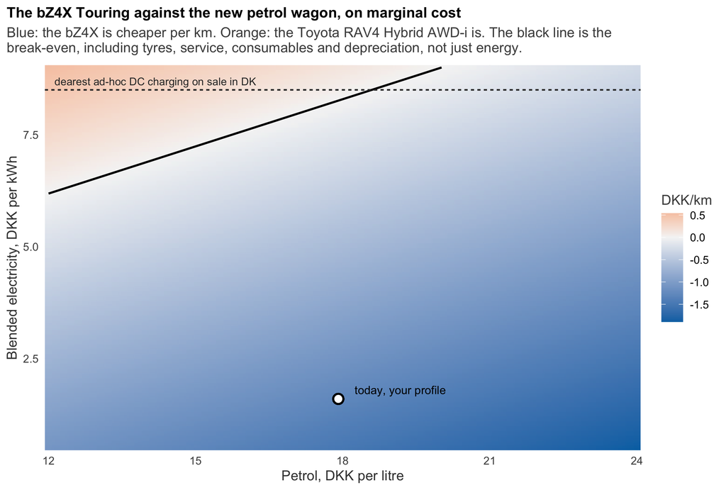

The break-even line is nearly flat, and it sits high. At today’s petrol price of 17.91 DKK/l, electricity would have to reach 8.35 DKK/kWh before the bZ4X’s total marginal cost exceeded the petrol wagon’s. The dearest electricity a Danish driver can realistically buy is ad-hoc DC at 8.50 DKK/kWh, and the flatness of the contour says why the margin is so wide: the two cars differ by 37.6 oere/km on everything that is not energy, and that difference already favours the electric car before a single kilowatt-hour is priced.

### 9.2 The depreciation elasticities

Section 5.4 showed the electric elasticity flipping sign under a change of controls. Scaling all three by a common factor puts a bound on what that fragility can do.

| Car | x 0.5 | x 1.0 | x 1.5 |
| --- | --- | --- | --- |
| Toyota bZ4X Touring AWD Active Tech | 0.75 | 0.79 | 0.82 |
| Tesla Model Y Long Range AWD | 0.66 | 0.69 | 0.73 |
| Toyota RAV4 Hybrid AWD-i | 1.87 | 2.06 | 2.22 |
| Skoda Octavia Combi 2.0 TDI 4x4 (2019) | 2.22 | 2.29 | 2.34 |

### 9.3 When the “elafgift” cut expires

The 2026-27 electricity tax cut is temporary. If the rate returns to its 2025 level of 90 oere/kWh before VAT, home charging rises by about 1.12 DKK/kWh.

On your profile the blended price would go from 1.59 to 2.55 DKK/kWh, and the bZ4X’s marginal cost from 0.79 to 0.97 DKK/km - a rise of 18.3 oere/km, or 3,658 DKK a year at 20,000 km. The electric car is still cheaper per kilometre than the Toyota RAV4 Hybrid AWD-i, by 109.2 oere/km. The cut is worth having but the conclusion does not depend on it.

### 9.4 How far would petrol have to fall?

Section 2.4 widened the fuel bands because today’s prices are near records and an eight-year hold is exposed to them coming back down. This section asks what that would actually do, by moving the pump price alone and leaving electricity where it is - the decorrelated case the bands cannot show.

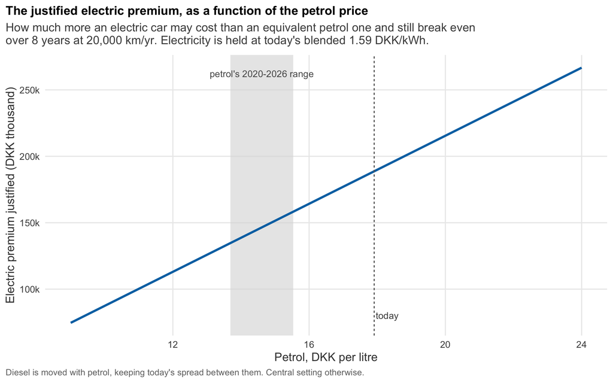

**The premium is roughly linear in the pump price, and the exposure is material.** At today’s 17.91 DKK/l an electric car is worth 189,876 DKK more; at the bottom of the band (13.50 DKK/l, roughly the 2024-25 level) it is worth 132,261 DKK, and at the top (23.00 DKK/l) 253,892 DKK. So the fuel-price question moves the answer by about 121,631 DKK across the credible range - which is the right order of magnitude to care about when the car itself costs 369,990 DKK.

**But the sign does not change anywhere on the grid.** Down to 9.00 DKK/l - below any Danish pump price this century - the petrol car still costs more per kilometre to run than the bZ4X, and the justified premium stays positive throughout. That is the reassuring half of the answer: **a fall in fuel prices changes how much the electric car is worth paying for, not whether it is worth paying more.**

> **The reason is structural rather than lucky.** Roughly half of a litre’s pump price in Denmark is duty and VAT - the VAT alone is a fifth of it - and the duty component is on a legislated upward path - the CO2 rate rose in 2025, diesel’s now exceeds petrol’s, and ETS2 arrives in 2027. A collapse in crude moves only the part of the price that is not tax, so even a halving of the oil price does not halve what you pay at the pump. The electricity side has the mirror-image asymmetry: its tax was cut to the EU minimum for 2026-27 and can only go back up, which is what section 9.3 prices. Neither of those is a forecast, but they do mean the two bands are not symmetric bets.

### 9.5 What is deliberately not modelled

Charging time and the value of it; the convenience of a five-minute fill against a thirty-minute stop, in both directions. Battery degradation as a per-kilometre cost and the warranty that covers it - that is a whole question of its own and it is answered in `battery-warranty/warranty-analysis.Rmd`. Company-car taxation, which changes the arithmetic completely for anyone on **“fri bil”**. Registration tax changes on future purchases. Road tolls and bridge fees. Anything to do with emissions other than through the taxes already priced in.

## 10. Verdict

**On the narrow question - what a kilometre costs, holding distance equal - electricity wins outright.** It takes the energy contest by a factor of 3.9 and keeps essentially all of it: the tyre penalty from carrying 325 kg more is cancelled by cheaper consumables and servicing. The bZ4X Touring’s marginal cost is 0.79 DKK/km against 2.06 for a new petrol wagon and 2.29 for a used diesel, and no setting of the energy prices reverses that. There is no trade-off to weigh at this level.

**Holding the odometer equal rather than the car confirms it.** A representative electric car is cheaper to run than the best combustion alternative at every odometer from 0 to 250,000 km, by 70.9 oere to 128.6 oere/km, and the gap widens with age rather than closing. That comparison contains no capital, so it cannot be an artefact of what the cars cost, and it holds mileage constant, so it cannot be an artefact of comparing new electric cars with worn-out diesels. The “periodiske afgifter” add 17.3 oere/km to that gap against diesel, and are being tightened further from 2027.

**That holds only with the car held fixed.** Across 104,000 to 449,990 DKK the marginal ranking and the total ranking are different rankings: the bZ4X carries 2.29 DKK/km of fixed cost at 20,000 km/yr, more than its entire marginal cost, and the cheapest car all-in is the **Tesla Model Y Long Range AWD (2021)**. The decision variable stops being the fuel and becomes the annual distance.

**The number to take away is the break-even cash price.** At 20,000 km/yr over 8 years an electric car is worth about **190,000 DKK more than an equivalent petrol car** and still breaks even, rising to roughly 280,000 DKK at 30,000 km/yr. That is the form the answer takes once mileage and price are both in play: not a fuel, but a price you are allowed to pay.

**Three things would change the answer, in descending order of how much:** the prices in `fuel-cost-cars.csv`, which drive section 8 entirely and which remain placeholders for 6 of 14 cars; the repair-hazard slope, which decides whether the cheap end of the fleet is a bargain or a trap; and the electric depreciation elasticity, whose sign depends on the regression controls. None of the three is a fuel price.

*Generated 06 September 2026 from `fuel-cost-per-km.Rmd`. Cost model in `R/fuel_model.R`; car list in `fuel-cost-cars.csv`; depreciation elasticities in `mileage_elasticity.csv`, regenerated by `Rscript "fuel-cost/mileage_elasticity.R"` from the repository root against `depreciation/bilbasen_data.csv` (6,888 listings).*